[figure not shown]

IFSC · IA na Eletrônica · 2026

# Zzzz… é *Aedes*?

Ensinando uma máquina a ouvir mosquitos.

**Luiz Eduardo do Nascimento Ciarallo**

z

z

Z

o problema

## Um mosquito, três doenças

dengue zika chikungunya

Saber **onde** e **quando** o *Aedes aegypti* aparece ajuda a combatê-lo.

Zzzz… é Aedes?

a ideia

## E se a armadilha pudesse ouvir?

[figure not shown]

a ideia do projeto

[video not shown]

antes de ouvir, olhe

# A asa em câmera lenta

Ao vivo, ela bate **centenas de vezes por segundo**.

cada batida empurra o ar…  
e isso é o zumbido

Vídeo (100× mais devagar): Mukundarajan, Hol, Castillo, Newby & Prakash, *eLife* 6:e27854 (2017) · CC BY 4.0

o som do mosquito

## Todo zumbido é uma nota musical

≈400batidas de asa por segundo

Asa mais rápida,  
som mais **agudo**.

som sintético, só para ilustrar (na versão animada)

tom típico do Aedes nas gravações: cerca de 400 Hz · caderno §3

o desafio

## Mas só a nota não basta

A máquina precisa ouvir o **som inteiro**, não só a nota.

clique ▸

faixa de tom de 8 em cada 10 gravações · caderno §3

de onde vêm os sons

## Dá para gravar com um celular

[video not shown]

mosquito na garrafa

[video not shown]

mosquitos decolando

Vídeos: Mukundarajan, Hol, Castillo, Newby & Prakash, *eLife* 6:e27854 (2017) · CC BY 4.0

como a máquina “ouve”

## O som vira imagem

[interactive chart not shown]

grave → agudo

tempo →

O computador não ouve: ele **olha uma foto do som**.

as faixas claras são o zumbido  
e os seus “ecos”

[video not shown]

Gravação real de um *Anopheles gambiae* (Mukundarajan et al., *eLife* 2017, CC BY 4.0)

à esquerda: ilustração · à direita: gravação real

como ela aprende

# A máquina aprende com exemplos

Aedes

outro mosquito

ruído

outro mosquito

Aedes

outro mosquito

2.167Aedes

3.050outros mosquitos

426ruídos

Ninguém escreve as regras. Mostramos milhares de gravações **com a resposta certa**, e ela descobre o padrão.

5.643 gravações de vários países e aparelhos · caderno §2 e §5

a regra de ouro

## Não vale colar na prova

Se o mesmo celular aparece no estudo e na prova, a máquina **decora o celular**, não o mosquito.

Nossa prova é sempre com um aparelho que ela **nunca ouviu**.

cada cor é um aparelho de gravação · caderno §7

o resultado: duas perguntas diferentes

## Avisa pouco, mas acerta quando avisa

Ela fica quieta em metade dos Aedes. Mas, **quando avisa, quase sempre é Aedes**.

clique ▸

gravações públicas, prova com aparelhos nunca ouvidos · caderno §11 e §12

espiando por dentro

## Em que parte do som ela presta atenção?

Bagunçamos **uma faixa do som por vez** e vemos o quanto ela piora.

barra alta = faixa importante

Ela usa o som **inteiro**, do grave ao agudo.

quanto a máquina piora ao embaralhar cada faixa de frequência · caderno §15

do computador para o mundo real

## Uma placa do tamanho de um dedo

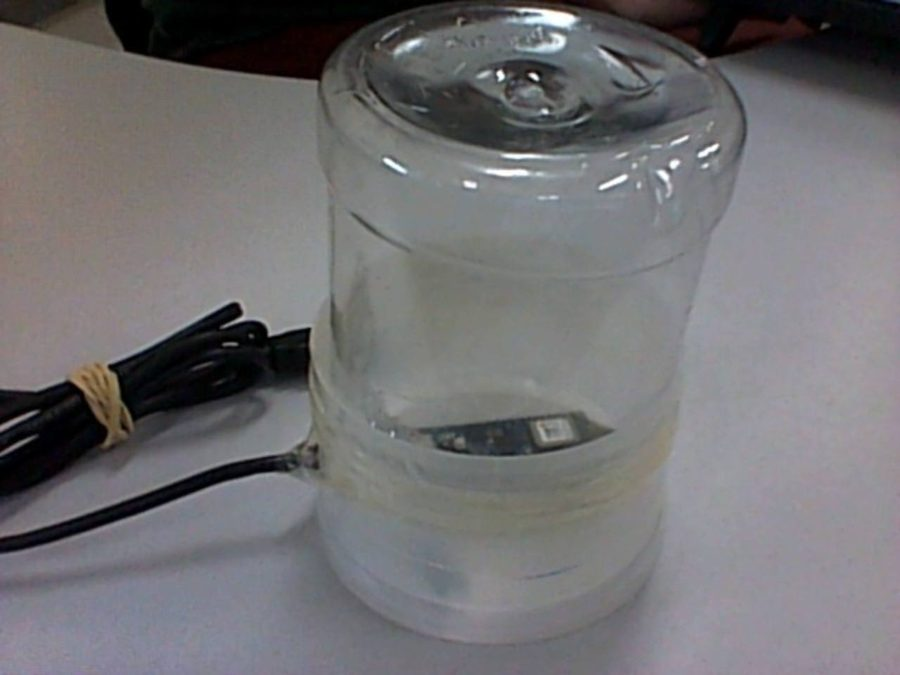

o protótipo: um Arduino num pote

[figure not shown]

Arduino Nano 33 BLE Sense · hoje a placa grava; decidir sozinha ainda é experimental

no laboratório

## Os mosquitos vêm de uma criação

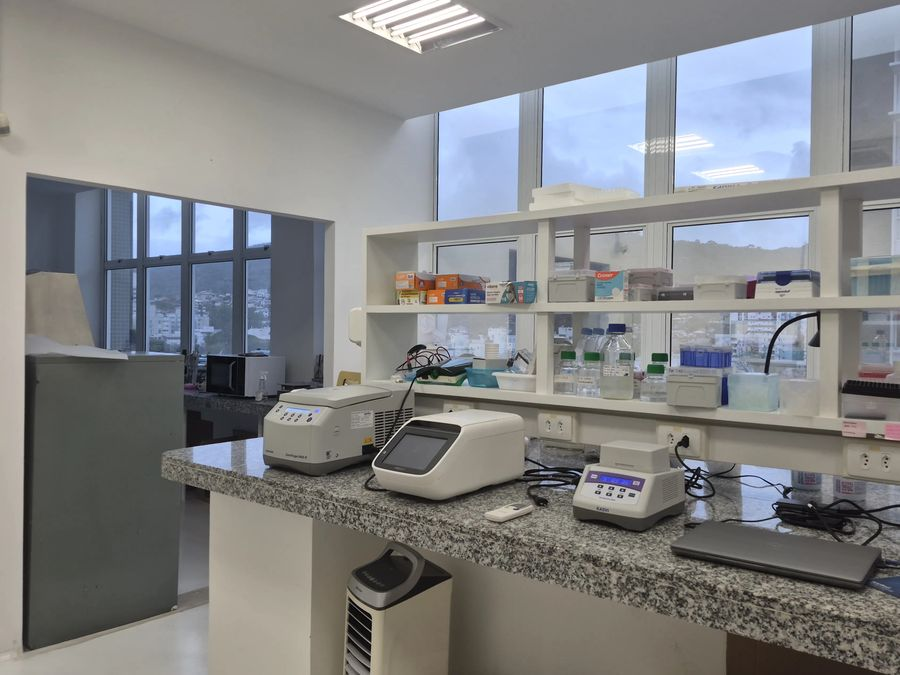

o laboratório

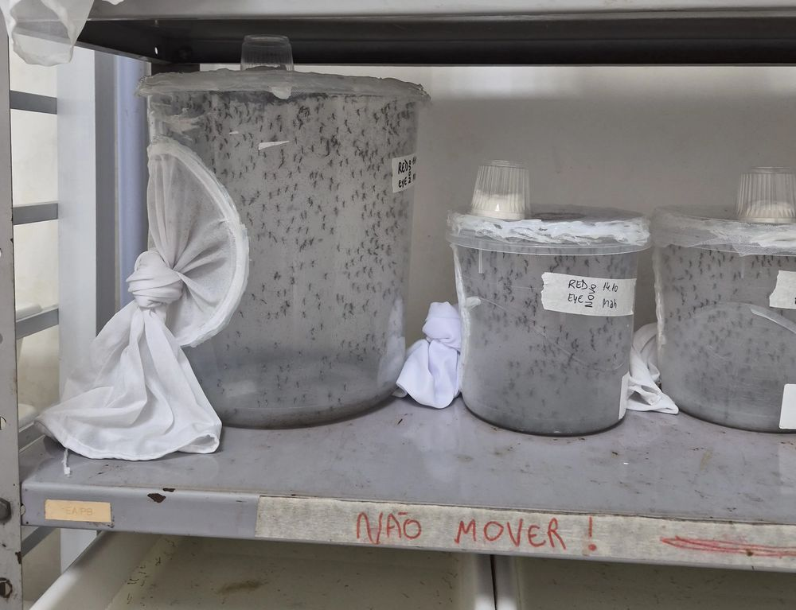

potes com tela, cheios de mosquitos

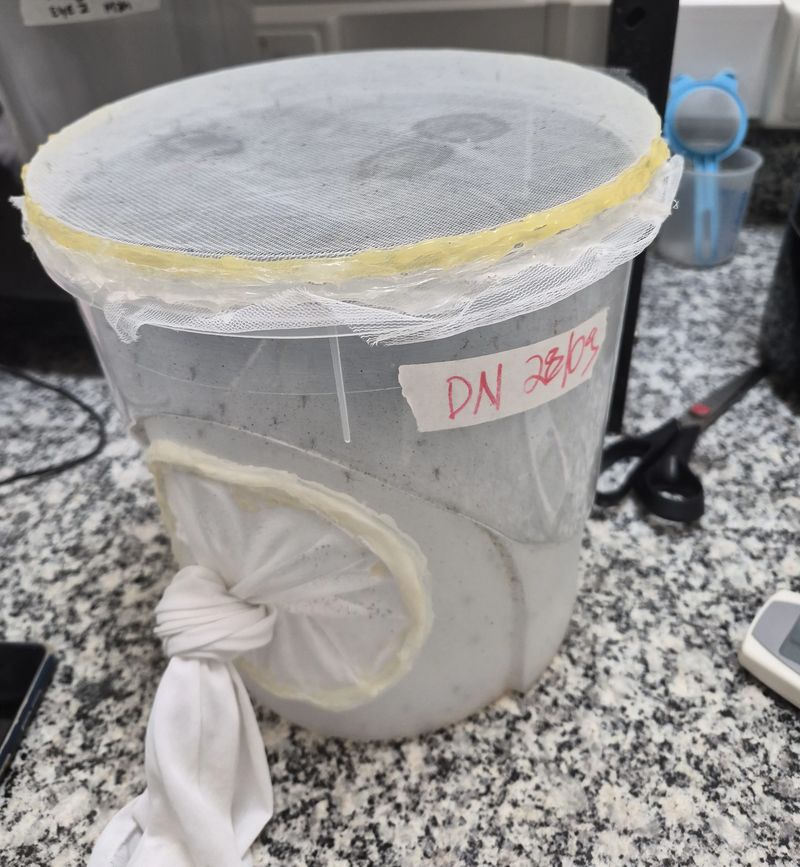

um pote de perto

Em cada pote, **centenas de mosquitos** criados no laboratório.

fotos do laboratório onde as gravações foram feitas

preparando a gravação

## Do pote para a armadilha

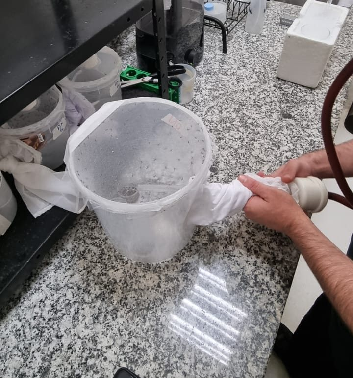

1 · pegar alguns com um aspirador

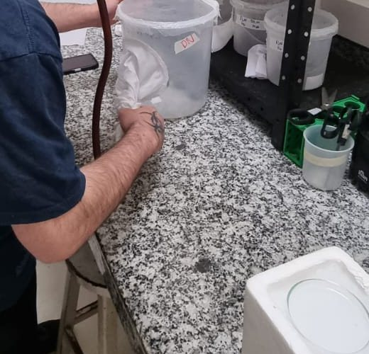

→

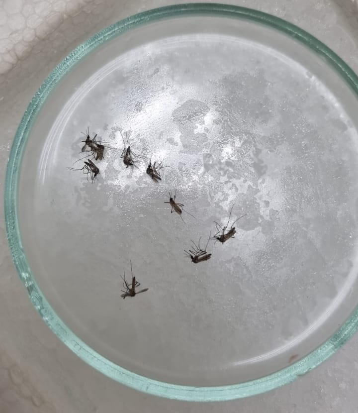

2 · um pouco de frio e eles adormecem

→

[video not shown]

3 · soltar na garrafa, com o Arduino

[figure not shown]

A armadilha é uma **garrafa cortada** com a placa dentro.

fotos e vídeo do laboratório · vídeo de 05/11/2026

a gravação

## O Arduino ouve, o computador grava

[figure not shown]

na tela, o som ao vivo

o Arduino, aqui dentro

a armadilha ligada ao computador

[figure not shown]

ao lado de um pote da criação

[figure not shown]

encostado no pote

O som vai pelo cabo. O computador **grava** e mostra a onda na hora.

fotos do laboratório · a 1ª é de 05/11 e a 2ª de 21/10/2026 (datas nas telas) · caderno §19

o teste com o nosso Arduino

## No laboratório: 8 em cada 10

81%

dos segundos de Aedes viraram aviso

3%

do ruído virou aviso

0%

do outro mosquito virou aviso

### Como chegamos lá

ponto de partida

**54%**

+ ouvir a armadilha vazia

**62%**

+ treinar com “enxames”

**69%**

+ conferir os dados de ouvido

**81%**

Prova sempre com **um dia inteiro** que a máquina nunca ouviu.

### Cuidado ao ler

São só **4 dias** de gravação e **uma** gravação de outra espécie.

promissor, ainda não comprovado

4 dias de gravação, um inteiro de fora por vez · caderno §19.16, §19.17 e §19.19

o que mais ajudou

## O truque: ouvir a armadilha vazia

Cada armadilha tem o seu barulho de fundo. **Descontando ele, o mosquito aparece.**

clique ▸

desenho ilustrativo · a mesma máquina foi de 54% para 62% de detecção · caderno §19.16

uma surpresa no caminho

## Quem errou: a máquina ou o gabarito?

69%→81%

Antes de culpar a máquina, **confira os dados**.

clique ▸

gravação de 30/09, segundo a segundo · a correção veio depois do primeiro teste: falta confirmar num dia novo · caderno §19.19

IA ajudando a fazer IA

## Fiz conversando com assistentes de IA

Claude Code

Anthropic

Codex

OpenAI

Gemini

Google

DeepSeek

e outros modelos

euMostre o zumbido deste mosquito num gráfico.

euVi um **erro de método** aqui. Corrija este ponto.

euConferi de novo. Agora sim: **aceito**.

aceito ✔

A IA acelera. A **responsabilidade** pelo resultado continua sendo minha.

esta apresentação, os gráficos e o código foram feitos com ajuda de IA, e conferidos

próximos passos

## O que ainda falta

1. ☐Gravar **outras espécies** na mesma armadilha.
2. ☐Gravar a **armadilha vazia** no começo de cada dia.
3. ☐Um **teste novo, em campo**, com as regras combinadas antes.

o que falta para levar o detector a campo · caderno §20

de onde veio tudo isso

## Referências

### Dados e trabalhos sobre mosquitos

1. Mukundarajan H., Hol F.J.H., Castillo E.A., Newby C., Prakash M. *Using mobile phones as acoustic sensors for high-throughput mosquito surveillance*. **eLife** 6:e27854, 2017. doi:10.7554/eLife.27854 — dataset Abuzz e vídeos (CC BY 4.0).
2. Kiskin I. et al. *HumBugDB: A Large-scale Acoustic Mosquito Dataset*. NeurIPS Datasets and Benchmarks, 2021. arXiv:2110.07607.
3. Sinka M.E. et al. *HumBug – An Acoustic Mosquito Monitoring Tool for use on budget smartphones*. **Methods Ecol. Evol.** 12, 2021. doi:10.1111/2041-210X.13663.
4. Torres I., Nakano M., Cime-Castillo J. et al. *Dengue-Infected Mosquito Detection with Uncertainty Evaluation based on Monte Carlo Dropout*. **IEEE Latin America Trans.** 23(2):135–143, 2025.
5. Vasconcelos D., Nunes N.J., Gomes J. *An annotated dataset of bioacoustic sensing and features of mosquitoes*. **Scientific Data** 7:382, 2020 — dataset Funchal.
6. Supratak A. et al. *MosquitoSong+: A noise-robust deep learning model for mosquito classification from wingbeat sounds*. **PLOS ONE** 19, 2024. doi:10.1371/journal.pone.0310121.
7. Paim K.O., Rohweder R., Recamonde-Mendoza M., Mansilha R.B., Cordeiro W. *Acoustic Identification of Ae. aegypti Mosquitoes using Smartphone Apps and Residual CNNs*. arXiv:2306.10091, 2023 — dados UFRGS.
8. Piczak K.J. *ESC: Dataset for Environmental Sound Classification*. ACM Multimedia, 2015 — ruídos ESC-50.

### Números, métodos e código

Todos os números desta apresentação saem de um único caderno, que vai do áudio bruto ao resultado e traz as referências dos métodos:

github.com/Lciarallo/mosquito-wingbeat

notebooks/detector_ternario_treinamento_teste_aplicacao.ipynb

Os quatro vídeos são de Mukundarajan et al., *eLife* 6:e27854 (2017), licença CC BY 4.0, recortados e comprimidos.

Zzzz… é Aedes?

para levar para casa

# O que aprendemos ouvindo mosquitos

1

O zumbido **diz quem é o mosquito**, e uma máquina consegue aprender a ouvir.

2

**Dados bem cuidados** ajudaram mais do que qualquer máquina maior.

3

No laboratório: **8 em cada 10**. Agora falta o teste no quintal.

Obrigado! perguntas? bzzz…

Luiz Eduardo do Nascimento Ciarallo · mosquito-wingbeat